# 1. Introdução

Neste relatório, pretende-se analisar os dados de gastos educacionais ao longo dos anos de 2005-2021, com foco especial para os anos de pandemia, verificando se houve uma queda substantiva desse tipo de gasto devido a ausência de aulas presenciais, medida necessária durante os períodos mais graves da pandemia, e à queda das receitas estaduais. Para isso, serão utilizados dados de gastos empenhados em educação (disponibilizado pelo SIOPE, Sistema de Informações sobre Orçamentos Públicos em Educação) e também dados de gastos em educação relativos ao mínimo constitucional, retirados dos Relatórios Resumidos de Execução Orçamentária (RREO) dos estados, na seção relativa ao Demonstrativo de Gastos na Manutenção e Desenvolvimento do Ensino (MDE).

Os objetivos principais deste trabalho são dois: 1) analisar se houve uma queda nos gastos estaduais em educação por meio da primeira fonte (SIOPE) e se esta queda está relacionada de fato com a pandemia de Covid-19; 2) Verificar se os estados respeitaram o mínimo constitucional de gasto em educação e a variedade dos gastos em educação, visualizando a diversidade e heterogeneidade dos gastos no Brasil.

Os dados foram coletados das fontes supracitadas e unificados em dois bancos de dados distintos, relativos a cada tipo de dado. Ambos os bancos estão no formato de *time series cross-sectional*, com uma observação para cada estado por ano. As próximas seções discutem os tipos de tratamentos que foram necessários para cada banco e algumas estatísticas descritivas e visualizações.

# 2. Dados Sobre os Gastos Empenhados em Educação (SIOPE)

## 2.1 Coleta dos Dados e Fontes

Esta seção discutirá como foi feita a coleta e o tratamento dos dados sobre os Gastos Empenhados em Educação nos Estados Brasileiros, disponível no SIOPE. O SIOPE, Sistema de Informações sobre Orçamentos Públicos em Educação, é parte do Fundo Nacional de Desenvolvimento da Educação (FNDE), do Ministério da Educação, e disponibiliza os dados enviados pelas unidades federativas em uma plataforma única. No entanto, nem todos os Estados e Municípios enviaram os seus relatórios para o SIOPE em todos os anos. Portanto, fontes complementares foram utilizadas quando necessárias. A tabela 1 mostra a disponibilidade dos dados e quais estados precisaram de complementos alternativos:

Tabela 1 - Disponibilidade dos Dados Estaduais

| Estado | Anos Disponíveis |
| --- | --- |
| AC | 2005-2021 |
| AL | 2005-2013 |
| AP | 2005-2021 |
| AM | 2005-2021 |
| BA | 2005-2021 |
| CE | 2005-2021 |
| DF | 2005-2017 |
| ES | 2005-2021 |
| GO | 2005-2021 |
| MA | 2005-2021 |
| MT | 2005-2021 |
| MS | 2005-2021 |
| MG | 2005-2013 |
| PA | 2005-2021 |
| PB | 2005-2021 |
| PR | 2005-2021 |
| PE | 2005-2020 |
| PI | 2005-2021 |
| RJ | 2005-2018 |
| RN | 2005-2017 |
| RS | 2005-2012 |
| RO | 2005-2020 |
| RR | 2005-2021 |
| SC | 2005-2021 |
| SE | 2005-2021 |
| SP | 2005-2021 |
| TO | 2005-2021 |

Notas: Dados retirados da plataforma do SIOPE.  
* A série histórica não está completa no SIOPE.

Para os estados que não possuíam a série histórica completa disponível no SIOPE, foram utilizados os RREOs, retirados das plataformas *online* das Secretarias de Fazenda (SEFAZ), Controladorias Gerais (Control) ou dos diários oficiais estaduais. No momento de carregamento dos dados, os dados originais e os complementos serão organizados em *dataframes* distintos, sendo unidos posteriormente por meio do *append*.

## 2.2 Organização, Limpeza e Manipulação dos Dados

A manipulação dos dados não foi simples, devido à vários problemas tanto na forma como eles são disponibilizados no SIOPE (em uma tabela de texto, não em uma planilha) quanto nas diferenças entre a forma como alguns dados são apresentados. Abaixo, descrevo o passo a passo da organização e limpeza dos dados:

**1.** Renomear as variáveis para um formato mais fácil de se manipular e utilizar nas visualizações, etc;

**2.** Remover espaços em branco no começo e no final das categorias da variável “Subfunções”, por meio da função “str_trim”;

**3.** Deixar as categorias desta variável no mesmo formato para que eu pudesse separar código da subfunção de seu nome (por meio de case_when);

**4.** Filtrar as subfunções de interesse e, finalmente, separar código de nome da subfunção;

**5.** Transformar as variáveis que estavam como textuais em númericas (fun_code, desp_emp, desp_liq, desp_pag). Também renomeei as subfunções para deixá-las mais fáceis para a manipulação.

O resultado dessa limpeza é mostrado nas tabela 2 e 3:

Tabela 2 - Amostra dos Dados Retirados do SIOPE

| Estado | Ano | Código da Função | Subfunção | Despesa Empenhada | Despesa Líquida | Despesas Pagas |
| --- | --- | --- | --- | --- | --- | --- |
| PI | 2018 | 364 | ens_sup | 18117262.4 | 15678852 | 11666253 |
| PI | 2020 | 366 | eja | 79757167.3 | 78852856 | 68203516 |
| MA | 2011 | 367 | ed_esp | 2649703.3 | 2649703 | 2649703 |
| GO | 2006 | 367 | ed_esp | 0.0 | 0 | 0 |
| SP | 2006 | 363 | ens_prof | 288751547.8 | 288751548 | 261128363 |
| PE | 2008 | 999 | total_ed | 1818060887.0 | 1770584507 | 1662287008 |
| RR | 2007 | 363 | ens_prof | 721531.9 | 0 | 0 |
| SC | 2014 | 363 | ens_prof | 43810590.5 | 41984775 | 41982502 |
| SE | 2010 | 361 | ens_fund | 352946795.6 | 352946796 | 352946796 |
| BA | 2015 | 362 | ens_med | 2238430447.0 | 2234741597 | 2175555757 |
| TO | 2015 | 999 | total_ed | 1118991631.4 | 1069562023 | 1064991099 |
| DF | 2015 | 362 | ens_med | 898538835.2 | 894580368 | 879891018 |
| MT | 2020 | 363 | ens_prof | 17784824.6 | 16778945 | 16741378 |
| GO | 2016 | 366 | eja | 46176969.4 | 7373736 | 477752 |
| PI | 2015 | 366 | eja | 62000000.0 | 62000000 | 62000000 |

Notas: Dados retirados da plataforma do SIOPE.  
* Para evitar conflitos, códigos arbitrários foram criados para total_ed e ens_inf.

Apesar do esforço de complementar os dados e evitar valores vazios, não foi possível retirar os valores de “Despesas Pagas” dos RREOs Estaduais. Por este motivo, a variável será removida da análise.

Tabela 3 - Amostra dos Dados Retirados de Fontes Complementares*

| Estado | Ano | Código da Função | Subfunção | Despesa Empenhada | Despesa Líquida |
| --- | --- | --- | --- | --- | --- |
| RJ | 2020 | 361 | ens_fund | 814983393 | 814983393 |
| MG | 2018 | 362 | ens_med | 2288367579 | 2187095903 |
| DF | 2019 | 999 | total_ed | 4807970169 | 4676991810 |
| AL | 2014 | 362 | ens_med | 182780545 | 167359970 |
| RS | 2013 | 999 | total_ed | 6530395167 | 6268105916 |
| MG | 2016 | 362 | ens_med | 2023805195 | 1879673540 |
| RN | 2021 | 999 | total_ed | 1672641050 | 1672641050 |
| MG | 2015 | 999 | total_ed | 8527865730 | 7666237373 |
| DF | 2018 | 362 | ens_med | 752206047 | 718656889 |
| RS | 2017 | 362 | ens_med | 1515211053 | 1515201508 |
| RS | 2021 | 361 | ens_fund | 3399902338 | 3387172072 |
| MG | 2021 | 999 | total_ed | 13549045426 | 12350041596 |
| AL | 2020 | 362 | ens_med | 223640772 | 211203782 |
| RJ | 2021 | 362 | ens_med | 2361832769 | 2358594353 |
| AL | 2021 | 999 | total_ed | 1624770708 | 1158831132 |

Notas: Dados complementares retirados das Secretarias de Fazenda, .  
* As fontes de cada observação se encontram na planilha original.

Nas próximas seções, os bancos serão unidos e se iniciará as análises descritivas e visualizações dos dados.

## 2.3 Visualização dos Dados.

Por meio da função *bind_rows*, os bancos foram unidos e os valores faltantes preenchidos. Algumas transformações finais no banco de dados são necessárias antes de se engendrar as visualizações e as análises descritivas dos dados. Precisamos transformar o banco de *long* para *wide* para que tenhamos uma linha por ano e por estado, com todos os valores de gastos por subfunção se tornando variáveis.

Para permitir comparações entre os valores gastos, deflacionaremos algumas variáveis. Utilizaremos o valor do INPC (Índice Nacional de Preços ao Consumidor), disponibilizado pelo IBGE. Ocorreram alguns problemas na transformação direta, então optei por criar uma variável INPC utilizando-se da variável de ano como base (valores calculados manualmente). Como a educação infantil não é obrigação do nível estadual, só os valores do ensino médio e fundamental (além dos totais) foram deflacionados.

Agora que temos estes valores deflacionados, podemos começar a fazer algumas visualizações. Uma possibilidade é a de avaliar o gasto total dos estados ao longo dos anos:

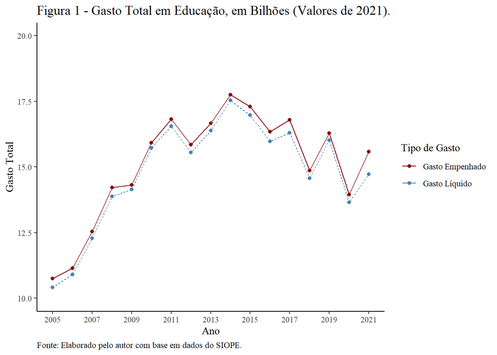

Como pode ser observado na figura, realmente há uma queda considerável nos gastos totais em educação para o ano de 2020. No entanto, a tendência de queda podia ser observada a partir do ano de 2014, o que torna difícil afirma que a causa da queda dos gastos em educação foi unicamente a pandemia. O mesmo comportamento é observado quando se tira a média dos gastos em educação, como mostra a figura 2

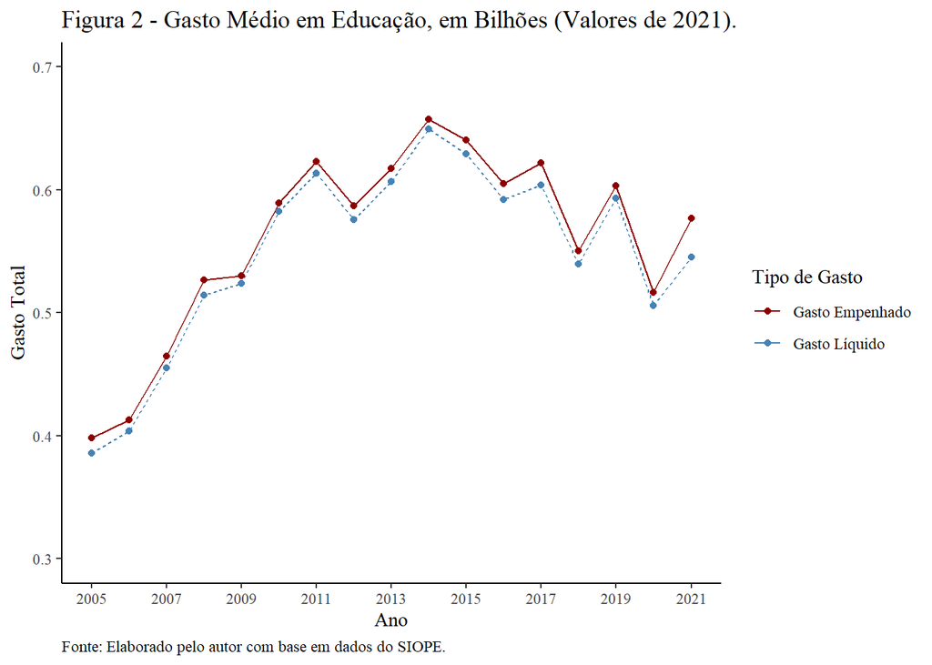

Podemos olhar também para a variação do gasto em educação. Utilizaremos o gasto líquido por que ele se refere ao valor dos serviços quando executados e, portanto, se aproxima mais do gasto realmente feito em educação em determinado ano. A figura 3 mostra o quanto o gasto em educação variou em determinado ano para todos os estados.

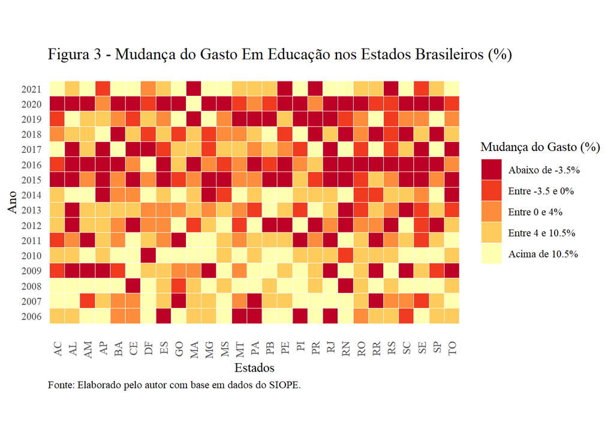

Para a criação das seções da variável na figura foram utilizados os valores da mediana, 3.81%, e dos quantis de 25% (-3.57%), e o de 75% (10.37%). De fato parece haver um decréscimo no gasto em educação para a maior parte dos estados em 2020 (com exceção de AP, MA, PA e PR), mas com recuperação parcial em 2021. A figura 4 mostra a variação no gasto nos estados brasileiros em três anos: 2019, 2020 e 2021.

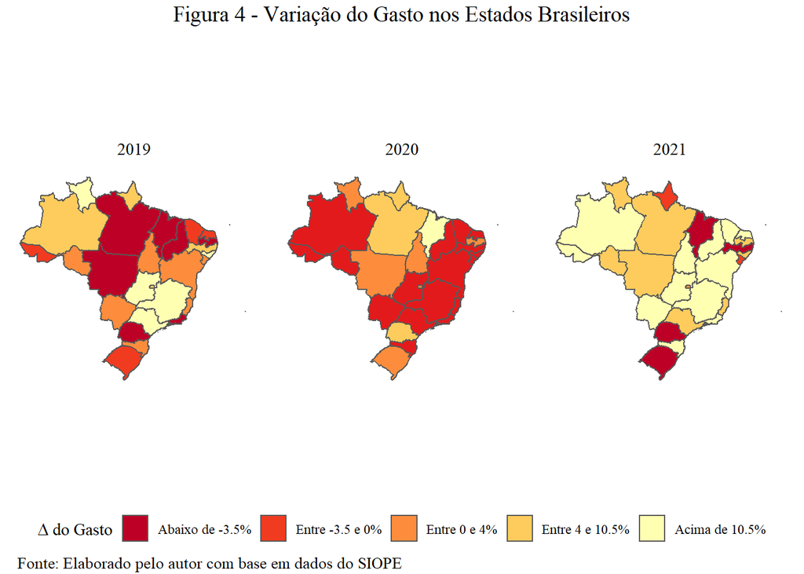

Pela imagem, percebe-se que a pandemia de fato derrubou a despesa líquida dos estados em educação. Com a queda da receita e, principalmente, da arrecadação do ICMS, ficou difícil para os estados manterem suas despesas em educação. No entanto, percebe-se que a maior parte deles recuperou a quantidade gasta em 2021, com o crescimento das despesas acima de 10,5% em vários estados. Podemos ver o quanto o ano de 2020 destoa dos outros por meio de um boxplot (figura 5).

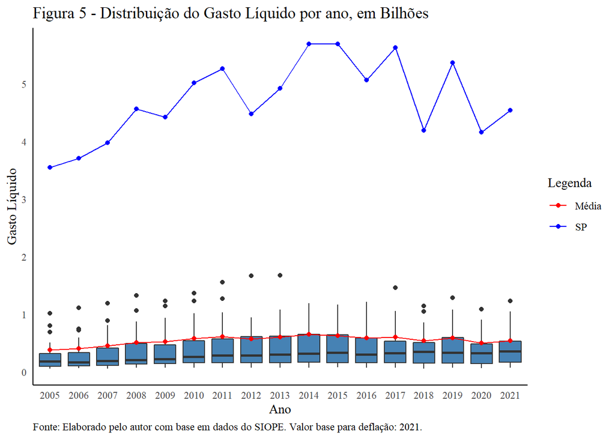

O primeiro passo é extrair as médias de 2020 e de 2021, que são de 0.51 e de 0.55 bilhões de reais, respectivamente. Agora, realizamos o teste:

Tabela 4 - Teste de Média para o ano de 2020

| Ano | Valor Estimado | P-Valor | Mínimo do I.C. | Máximo do I.C. |
| --- | --- | --- | --- | --- |
| 2020 | 0.5481386 | 0.3047999 | 0.4666871 | 0.62959 |
| 2021 | 0.5481386 | 0.9433227 | 0.4666871 | 0.62959 |

Fonte: Dados do SIOPE

Nenhum dos p-valores apresentados pelos testes, de 0.3 para 2020 e de 0.94 para o ano de 2021, permitem afirmar que a média de gastos nestes anos foi diferente da série histórica. Portanto, apesar dos gastos terem sofrido uma redução, esta não parece ter sido substantiva. A figura 6 mostra os resultado desses testes de outra forma.

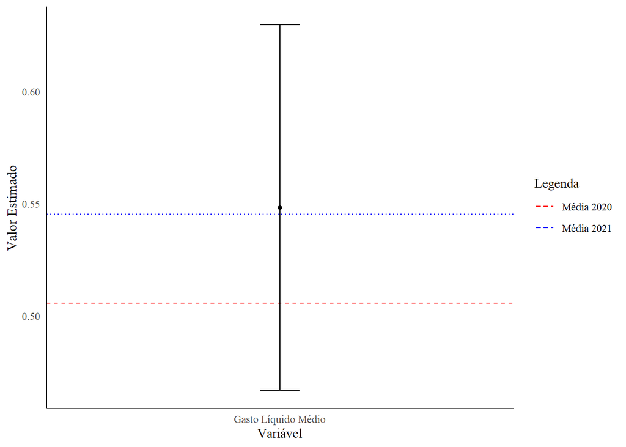

Nela pode-se observar que os valores das médias de 2020 e 2021 se encontram dentro do intervalo de confiança estimado pelo teste. Portanto, os gastos médios de 2020 e 2021 não diferiram substantivamente de maneira estatística dos outros anos da série histórica, ao menos no nível estadual. Como dito anteriormente, e como mostra a figura 7, São Paulo é um outlier considerável para esses dados. Podemos refazer o teste de média removendo essa observação para ver se nossas conclusões sobre a diferença entre os gastos em 2020 e 2021 em comparação com os outros anos são, de fato, robustas.

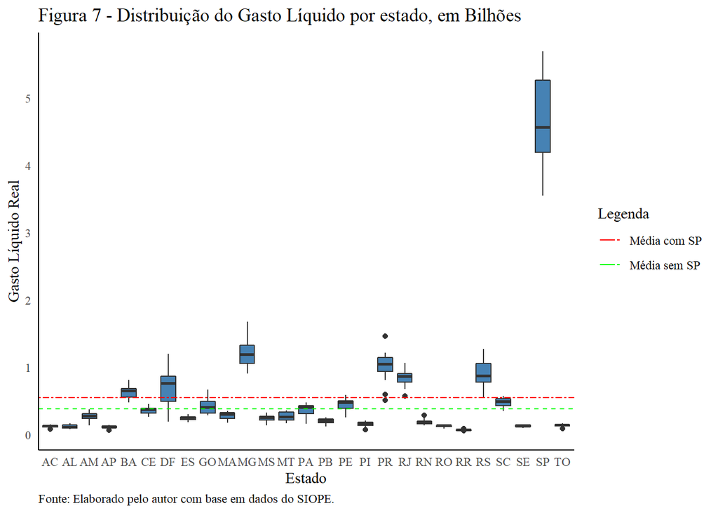

Tabela 5 - Teste de Média para os ano de 2020 e 2021, sem SP

| Ano | Valor Estimado | P-Valor | Mínimo do I.C. | Máximo do I.C. |
| --- | --- | --- | --- | --- |
| 2020 | 0.3878092 | 0 | 0.357301 | 0.4183173 |
| 2021 | 0.3878092 | 0 | 0.357301 | 0.4183173 |

Fonte: Dados do SIOPE

Vemos, na tabela 5, que os P-valores nos permitem rejeitar a hipótese nula de que as médias de 2020 e 2021 são iguais as dos outros anos. No entanto, como nos mostra a figura 8, as médias para os anos em análise são maiores do que a média da série histórica.

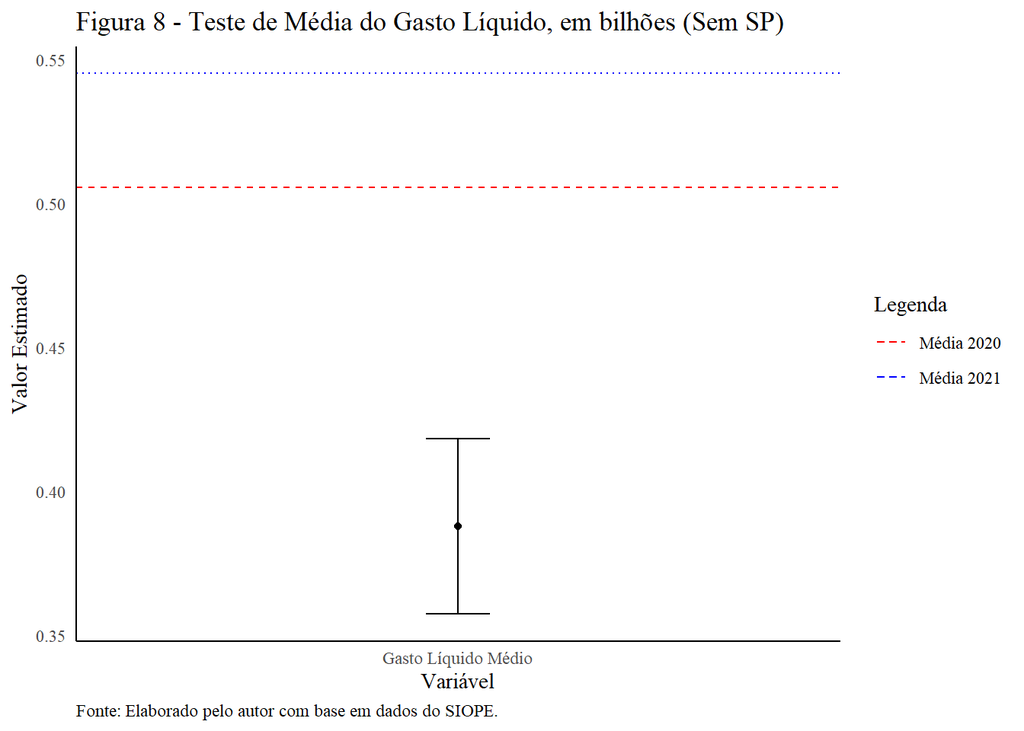

# Gastos por nível de educação

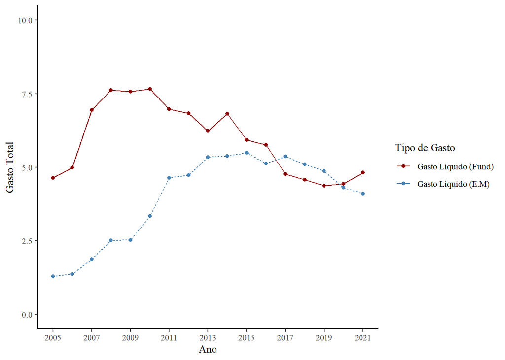